# Impedância hidráulica e vulnerabilidade geotécnica como amplificadores da erodibilidade efetiva em Plintossolos tropicais com erosão linear

Autor

Afiliação

Luiz Diego Vidal Santos

Universidade Estadual de Feira de Santana

Data de Publicação

Resumo

Palavras-chave

USLE correction factor, iron cementation, dispersible fraction, jet erosion test, hierarchical Bayesian calibration

# 1 Introdução

Em solos tropicais, a erosão hídrica acelerada constitui uma das principais ameaças à sustentabilidade, com taxas de perda que excedem a pedogênese natural em ordens de grandeza nas vertentes mais vulneráveis (Poesen 2018). A Equação Universal de Perdas de Solo (USLE), na formulação original de Wischmeier e Smith (1978) e na revisão RUSLE de Renard et al. (1997), permanece como o modelo empírico mais adotado globalmente para estimativa de erosão laminar e em sulcos, estruturando a perda de solo como produto de seis fatores que descrevem erosividade da chuva, erodibilidade do solo, comprimento e declividade da rampa, cobertura vegetal e práticas conservacionistas.

Na USLE/RUSLE, o fator de erodibilidade ($K$) sintetiza a suscetibilidade intrínseca do solo ao destacamento e transporte por impacto de gotas e escoamento laminar. Sua estimativa pelo nomograma de Wischmeier, Johnson, e Cross (1971) depende de cinco propriedades do horizonte superficial, notadamente granulometria, matéria orgânica, estrutura e permeabilidade, e foi calibrada em parcelas experimentais de solos temperados do Meio-Oeste dos Estados Unidos, em condições edáficas e climáticas distintas dos trópicos úmidos (Alewell et al. 2019). A aplicação desse nomograma a solos tropicais intemperizados enfrenta limitações reconhecidas na literatura.

Solos com elevada fração argilosa (> 40%) mas com argilas 1:1 (caulinita) e oxi-hidróxidos de ferro e alumínio apresentam microagregação estável que reduz a erodibilidade efetiva em relação ao previsto pela granulometria (Silva et al. 2009; Bertoni e Lombardi Neto 2017), ao passo que em Plintossolos com impedância hidráulica em subsuperfície a erodibilidade efetiva pode superar a prevista porque a geração de escoamento concentrado sob intensidades de chuva recorrentes amplifica o destacamento em magnitudes que a equação empírica não prevê (Poesen 2018; Cassol et al. 2023).

Essa discrepância é particularmente aguda quando a erosão transcende o domínio laminar e em sulcos para o qual a USLE foi calibrada. Em vertentes com ravinas ativas, a perda de solo integra contribuições de incisão vertical, instabilidade lateral localizada e recuo de cabeceira, processos governados por tensão cisalhante do escoamento concentrado e por resistência geotécnica do substrato (coesão, ângulo de atrito, pressões neutras) que o fator $K$ não contempla (Poesen et al. 2003; Liu et al. 2021). Modelos como EGEM, WEPP e SWAT tratam erosão em ravinas como processo separado, porém sua complexidade computacional e demanda de dados limitam a adoção em contextos operacionais de planejamento (Alewell et al. 2019).

Três condições edáficas podem convergir em Plintossolos tropicais para amplificar a erodibilidade efetiva de modo não captado pelo nomograma (Padmanabhan e Eswaran 2005; Ribeiro Filho et al. 2023). A impedância hidráulica associada à presença de plintita em subsuperfície pode reduzir substancialmente a velocidade de infiltração básica (VIB) e favorecer a transição do regime de percolação vertical para escoamento hortoniano quando a intensidade da chuva excede a capacidade de infiltração do perfil (Padmanabhan e Eswaran 2005; Wang et al. 2020; Horton 1933). A saturação por alumínio elevada nos horizontes subsuperficiais pode restringir a colonização radicular e reduzir a cobertura vegetal, expondo o horizonte a destacamento direto e retroalimentando a amplificação da erodibilidade (Rao et al. 2016; Vannoppen et al. 2015). A proximidade geotécnica ao limiar de ruptura por cisalhamento, expressa pela razão entre profundidade da feição e altura crítica de Rankine ($H/H_c$), pode introduzir contribuição adicional de instabilidade lateral quando a feição se aproxima do equilíbrio limite (Poesen et al. 2003; Sidorchuk 2006).

Nos Tabuleiros Costeiros de Sergipe, trabalho anterior caracterizou um Plintossolo Háplico Distrófico com VIB de 1,53 cm/h nos terços intermediário e inferior da vertente, saturação por alumínio de 84–99% nos horizontes subsuperficiais, coesão sob saturação de 13,02 kPa e ângulo de atrito de 34,93° (horizonte Bt, 1,20 m), resultando em altura crítica de corte vertical $H_c$ = 3,35 m. Seis feições erosivas com profundidade de 0,40–1,50 m e razão $H/H_c$ de 0,12–0,45 foram classificadas por inferência fuzzy Mamdani como ravinas transicionais a voçorocas incipientes. Esses dados sugerem que a convergência das três condições amplificadoras eleva a erodibilidade efetiva do Plintossolo acima do previsto pelo nomograma, motivando a proposição de um fator de correção específico.

Para verificar se essa amplificação é atribuível às propriedades diagnósticas do Plintossolo, e não a um artefato generalizável a qualquer solo tropical intemperizado, torna-se necessário o confronto com classes pedológicas contrastantes. Latossolos Vermelho-Amarelos da mesma região apresentam VIB tipicamente superior a 6 cm/h, saturação por alumínio inferior a 30% e feições erosivas lineares ausentes ou incipientes, constituindo controle negativo no qual se espera erodibilidade observada próxima à prevista pelo nomograma (Silva et al. 2009; Bertoni e Lombardi Neto 2017). Argissolos Vermelho-Amarelos, por sua vez, compartilham com o Plintossolo o gradiente textural abrupto (horizonte Bt adensado) que gera impedância hidráulica e redução da VIB, porém sem plintita e frequentemente com saturação por alumínio intermediária, operando como controle parcial que permite isolar o efeito do regime hidráulico das demais amplificações.

Até o presente momento, nenhum estudo propôs um fator de correção para o $K$ da USLE/RUSLE que incorpore simultaneamente impedância hidráulica subsuperficial, toxicidade edáfica por alumínio e vulnerabilidade geotécnica à instabilidade lateral potencial, nem validou tal formulação por confrontação multi-classe entre solos tropicais com gradientes contrastantes dessas propriedades. A literatura tampouco derivou a erodibilidade de Plintossolos a partir de princípios mecânicos do solo cimentado por óxidos de ferro, limitando-se a correções empíricas do nomograma que não captam a coesão adicional proveniente da cimentação ferruginosa, a qual altera simultaneamente a agregação primária e a condutividade hidráulica, tornando a resistência ao cisalhamento úmido insatisfatoriamente representada por texturas-padrão (Alewell et al. 2019). A ausência de um modelo mecanístico de dispersão que integre fração de ferro livre, densidade aparente e hidrofobicidade pós-secagem para predizer a fração dispersável sob chuva impede a distinção entre erodibilidade aparente (captada pelo nomograma) e erodibilidade efetiva (condicionada pela resposta do material cimentado a ciclos de umedecimento e secagem).

Partindo desse quadro, este estudo propõe a fundamentação teórica e o desenho experimental multi-classe para calibração de um fator de correção multiplicativo ($K_{plint}$) que incorpora regime hidráulico, toxicidade edáfica e vulnerabilidade geotécnica ao fator $K$ da USLE/RUSLE.

A formulação operacional em campo permanece restrita a esses três amplificadores, enquanto o modelo mecanístico de dispersão atua como submodelo auxiliar para quantificar, em laboratório, a discrepância entre a fração textural fina e a fração efetivamente mobilizável do material cimentado. O Plintossolo opera como alvo de calibração, o Latossolo como controle negativo e o Argissolo como controle parcial, configurando uma cadeia causal que preserva interpretabilidade física e permite separar a contribuição de cada mecanismo amplificador.

# 2 Fundamentação teórica

## 2.1 A USLE e o nomograma de erodibilidade

A USLE consolidou-se como ferramenta de referência para estimar perda média anual de solo, comparar cenários de manejo e orientar práticas conservacionistas em áreas agrícolas, porque transforma erosividade da chuva, erodibilidade do solo, relevo, cobertura e práticas de controle em uma métrica operacional de perda de solo (Wischmeier e Smith 1978; Renard et al. 1997; Benavidez et al. 2018). Nessa estrutura, a perda de solo média anual é expressa como produto de seis fatores (Equação 1).

$$A = R \times K \times L \times S \times C \times P
\tag{1}$$

onde $A$ é a perda de solo média anual (t ha$^{-1}$ ano$^{-1}$), $R$ o fator de erosividade da chuva (MJ mm ha$^{-1}$ h$^{-1}$ ano$^{-1}$), $K$ o fator de erodibilidade do solo (t h MJ$^{-1}$ mm$^{-1}$), $L$ o fator de comprimento de rampa, $S$ o fator de declividade, $C$ o fator de cobertura e manejo e $P$ o fator de práticas conservacionistas. O fator $K$ é estimado pela equação do nomograma (Equação 2).

$$100\,K = 2{,}1 \times 10^{-4}\,M^{1{,}14}\,(12 - a) + 3{,}25\,(b - 2) + 2{,}5\,(c - 3)
\tag{2}$$

onde $M = (\%\text{silte} + \%\text{areia muito fina}) \times (100 - \%\text{argila})$, $a$ é o teor de matéria orgânica (%), $b$ o código de estrutura do solo (1–4) e $c$ o código de permeabilidade (1–6).

## 2.2 Modelo mecanístico de dispersão em solos cimentados por óxidos de ferro

Na calibração convencional do fator $K$, o ajuste empírico entre propriedades do horizonte superficial e perda de solo observada trata a erodibilidade como propriedade escalar determinada por granulometria, matéria orgânica, estrutura e permeabilidade, sem representar diretamente o mecanismo pelo qual o material edáfico é mobilizado sob ação da chuva. Essa simplificação é útil para aplicação operacional, mas pode subestimar ou superestimar a resposta de solos tropicais quando a estabilidade de agregados, a mineralogia de óxidos e a conectividade hidráulica do perfil deslocam o solo para fora do domínio de calibração original (Römkens et al. 1997; Alewell et al. 2019). Em Plintossolos, a cimentação parcial por oxi-hidróxidos de ferro (goethita e hematita) pode conferir coesão adicional à matriz que não é captada pelo nomograma, pois este assume que a fração dispersável coincide com a fração textural fina (Silva et al. 2009; Ribeiro Filho et al. 2023).

A plintização altera simultaneamente a agregação primária, pela formação de pontes de óxidos entre domínios cauliníticos, e a condutividade hidráulica, pela obstrução parcial de macroporos com material ferruginoso precipitado, de modo que a resistência ao destacamento do agregado cimentado pode diferir da resposta do mesmo material após remoção seletiva de ferro livre (Silva et al. 2009; Ribeiro Filho et al. 2023).

A fração dispersável ($f_d$) será estimada a partir de um modelo de mistura que integra a fração de ferro livre extraída por ditionito-citrato-bicarbonato ($Fe_d$, g kg$^{-1}$), a densidade aparente ($\rho_b$, g cm$^{-3}$) e o índice de hidrofobicidade pós-secagem ($R_{WDPT}$, tempo de penetração da gota em segundos) como variáveis preditoras da proporção do solo efetivamente suscetível à desagregação sob impacto de gotas e escoamento raso (Equação 3).

$$f_d = \dfrac{f_{tex}}{1 + a_1 \cdot Fe_d^{a_2} \cdot \rho_b^{a_3} \cdot R_{WDPT}^{a_4}}
\tag{3}$$

onde $f_{tex}$ é a fração dispersável teórica calculada pela granulometria convencional (equivalente ao parâmetro $M$ do nomograma) e os coeficientes $a_1$–$a_4$ são parâmetros a calibrar experimentalmente por ensaios de dispersão sob chuva simulada em amostras com teores contrastantes de ferro livre. A forma funcional assegura que $f_d \to f_{tex}$ quando a cimentação por ferro é desprezível ($Fe_d \to 0$) e $f_d \to 0$ quando a cimentação é extrema, comportamento fisicamente coerente com a estabilização progressiva de microagregados por pontes de óxidos (Bertoni e Lombardi Neto 2017).

A fração dispersável estimada pela Equação 3 será propagada para o cálculo da energia de desagregação específica ($E_d$, J kg$^{-1}$), definida como a energia cinética de chuva necessária para mobilizar uma unidade de massa do material cimentado em relação ao material desferrificado (Equação 4).

$$E_d = E_0 \cdot \left(\dfrac{f_{tex}}{f_d}\right)^{n_d}
\tag{4}$$

onde $E_0$ é a energia de desagregação de referência para o solo desferrificado (calibrada em laboratório por chuva simulada sobre amostra tratada com ditionito) e $n_d$ o expoente de resistência à desagregação. A razão $f_{tex}/f_d > 1$ indica que a cimentação por ferro eleva a energia necessária para destacar partículas em relação ao previsto pela textura, quantificando a discrepância mecanística que o nomograma ignora. Nesta proposta, $E_d$ não constitui um quarto fator explícito do $K_{plint}$, mas uma variável mecanística auxiliar usada para verificar se a cimentação ferruginosa altera a resistência intrínseca ao destacamento na mesma direção observada na resposta hidrológica e na erodibilidade medida em campo.

A validação do modelo de mistura requer ensaios de dispersão sob chuva simulada em amostras naturais e desferrificadas do mesmo horizonte, conforme descrito na seção 5.4, permitindo estimar $a_1$–$a_4$ e $n_d$ independentemente dos parâmetros do fator de correção ($n_1$, $\beta_{max}$, $k_2$, $k_3$, $n_3$). Essa separação aloca o modelo de dispersão no nível laboratorial da cadeia causal, ao passo que os termos $\alpha$, $\beta$ e $\gamma$ permanecem como amplificadores operacionais calibrados em parcela, evitando a colinearidade que compromete regressões diretas com muitos preditores simultâneos.

## 2.3 Estrutura do fator de correção $K_{plint}$

O modelo mecanístico apresentado na seção anterior não introduz um quarto fator multiplicativo, mas fornece a base laboratorial para interpretar fisicamente a amplificação estimada em campo. Assim, para Plintossolos tropicais com erosão linear, a erodibilidade corrigida é expressa como produto do fator $K$ do nomograma de Wischmeier por três termos de correção adimensionais (Equação 5). A fração dispersável e a energia de desagregação derivadas da Equação 3 e da Equação 4 funcionam como variáveis auxiliares de condicionamento e validação, enquanto a correção operacional permanece restrita aos três mecanismos observáveis em escala de parcela.

$$K_{plint} = K_{RUSLE} \times \alpha(VIB) \times \beta(m_{Al}) \times \gamma\!\left(\dfrac{H}{H_c}\right)
\tag{5}$$

onde $K_{RUSLE}$ é o fator de erodibilidade obtido pela Equação 2 ou por medição direta em parcela padrão, $\alpha$ o fator de amplificação por regime hidráulico, $\beta$ o fator de penalização por toxicidade edáfica e $\gamma$ o fator de vulnerabilidade geotécnica. A estrutura multiplicativa implica que cada fator opera como amplificador independente sobre a erodibilidade basal. A premissa de independência entre $\alpha$, $\beta$ e $\gamma$ é plausível quando os mecanismos atuam em camadas e escalas distintas (regime hidráulico em superfície, toxicidade na zona radicular, geotecnia em parede de talude), mas pode ser violada em campo, por exemplo, quando a redução de VIB e a redução de coesão compartilham a mesma gênese de compactação ou alternação sazonal de umidade. Essa colinearidade será diagnosticada pelo cálculo de fatores de inflação de variância (VIF) entre $\log\alpha$, $\log\beta$ e $\log\gamma$ no espaço multiplicativo, com VIF > 5 sinalizando colinearidade preocupante, e pelo ajuste de uma especificação aditiva-com-interação ($\delta = 1 + \alpha' + \beta' + \gamma' + \eta\,\alpha'\beta'$) como modelo competidor, sendo a estrutura multiplicativa preferida apenas se o ganho preditivo (AICc) compensar a perda de identificabilidade.

Quando nenhuma das três condições amplificadoras está presente (solo bem drenado, ausência de toxicidade por alumínio, ausência de feição erosiva profunda), os três fatores assumem valor unitário e $K_{plint}$ se reduz a $K_{RUSLE}$. Quando as três condições convergem, como em Plintossolos com voçorocas ativas, os fatores se multiplicam e a razão $\delta = K_{plint}/K_{RUSLE} = \alpha \times \beta \times \gamma$ pode atingir valores de 2 a 10 ou superiores (Poesen 2018). A variável $\delta$ é adimensional e independente do valor absoluto de $K_{RUSLE}$, permitindo comparar o grau de amplificação entre classes pedológicas com erodibilidade basal distinta.

## 2.4 Fator de amplificação por regime hidráulico $\alpha(VIB)$

No nomograma de Wischmeier, a permeabilidade recebe peso relativamente baixo no cômputo de $K$ (código 1–6, contribuição máxima de 7,5% no valor final). Em solos com boa drenagem interna, a maior parte da precipitação infiltra e percola verticalmente, gerando pouco escoamento superficial e, consequentemente, baixa energia disponível para destacamento e transporte de partículas (De Roo e Riezebos 1992). Em Plintossolos, a presença de plintita ou petroplintita em subsuperfície pode reduzir a condutividade hidráulica saturada quando há contraste estrutural ou poral entre horizontes, criando barreira parcial à percolação e favorecendo a saturação do perfil sob chuvas de maior intensidade (Padmanabhan e Eswaran 2005; Ribeiro Filho et al. 2023). Essa resposta, contudo, não deve ser assumida como uniforme para toda a classe, pois Plintossolos com textura, estrutura e consistência pouco contrastantes entre horizontes superficiais e subsuperficiais podem apresentar gradiente hidráulico menos abrupto. A VIB, determinada em campo por infiltrômetro de duplo anel, reflete essa impedância integrada ao longo do perfil e constitui a variável de entrada mais acessível para expressar o contraste hidrológico entre classes de solo (Bertoni e Lombardi Neto 2017).

No Plintossolo estudado, os valores preliminares de VIB variam de 3,13 cm/h no terço superior a 1,53 cm/h no intermediário, dados que serão tratados na seção de área de estudo e usados apenas como referência para parametrização inicial do termo hidráulico. Essa faixa sugere maior probabilidade de geração de escoamento superficial quando a intensidade da chuva excede a capacidade de infiltração local, sem pressupor que todos os horizontes do perfil apresentem contraste hidráulico abrupto.

Como forma funcional para $\alpha$, propõe-se uma lei de potência referenciada a um limiar de VIB acima do qual o perfil opera predominantemente sob regime de percolação vertical e a contribuição da impedância hidráulica à erodibilidade é negligenciável (Equação 6).

$$\alpha(VIB) = \left(\dfrac{VIB_{ref}}{VIB_{local}}\right)^{n_1}
\tag{6}$$

onde $VIB_{ref}$ é o limiar de referência (cm/h) acima do qual o perfil opera sob percolação vertical predominante e $n_1$ o expoente de amplificação a calibrar. O expoente $n_1$ governa a intensidade da penalização à medida que a VIB decresce, de modo que para $n_1 = 1$ a relação é linear e reduzir a VIB pela metade duplica $\alpha$, enquanto valores de $n_1 > 1$ produzem penalização mais severa em solos com impedância acentuada e $n_1 < 1$ atenua a diferenciação entre solos com VIB moderada e muito baixa (Kinnell 2005). O limiar $VIB_{ref}$ = 6,0 cm/h corresponde ao limite inferior de solos classificados como bem drenados na pedologia tropical (Empresa Brasileira de Pesquisa Agropecuária 2018) e foi adotado como ponto de neutralidade ($\alpha = 1$) do fator hidráulico.

Para $VIB_{local} \geq VIB_{ref}$, adota-se $\alpha = 1$ (sem correção). Para $VIB_{local} < VIB_{ref}$, $\alpha > 1$ com magnitude crescente conforme o inverso da infiltração. Valores de VIB medidos no sítio experimental serão usados na seção de calibração para estimar $\alpha$ por posição da vertente, evitando que simulações paramétricas sejam apresentadas como evidência de resultado no referencial teórico.

## 2.5 Fator de penalização por toxicidade edáfica $\beta(m_{Al})$

Em solos tropicais ácidos, a saturação por alumínio elevada pode restringir o crescimento radicular, reduzir a exploração hídrica e nutricional do perfil e limitar a capacidade de recomposição da cobertura vegetal em superfícies expostas (Rao et al. 2016; Vannoppen et al. 2015). Em Plintossolos submetidos à incisão erosiva, esse mecanismo torna-se relevante quando horizontes subsuperficiais com maior saturação por alumínio passam a compor a superfície ativa de escoamento ou as paredes das feições.

Embora o fator $C$ da USLE capture parcialmente o efeito da cobertura, ele não incorpora o mecanismo causal edáfico que a determina nem a retroalimentação entre perda de cobertura, exposição do horizonte e amplificação da erodibilidade, processo cíclico documentado em solos álicos tropicais (Cassol et al. 2023).

Como forma funcional, propõe-se uma sigmoide logística com inflexão no limiar de caráter álico (Equação 7). Define-se $m_{eff}$ como a saturação por alumínio efetivamente exposta ao processo erosivo, computada como média ponderada entre o horizonte superficial e o horizonte diagnóstico subsuperficial pela proporção de exposição observada na parcela ($m_{eff} = w_{Ap}\,m_{Ap} + w_{sub}\,m_{sub}$, com $w_{sub}$ estimado pela fração de área da parcela com horizonte subsuperficial aflorante). Essa definição evita o viés conceitual de aplicar diretamente $m_{sub}$ a parcelas com cobertura superficial preservada, situação em que a fitotoxicidade não opera sobre a vegetação ativa, e foi adotada após inspeção do gradiente vertical (15,2% no Ap a 99,2% no BAc) que tornaria a escolha do horizonte determinante para o valor de $\beta$.

$$\beta(m_{eff}) = 1 + \dfrac{\beta_{max} - 1}{1 + \exp\!\left[-k_2\,(m_{eff} - m_0)\right]}
\tag{7}$$

onde $m_{eff}$ é a saturação por alumínio efetiva (%, 0–100), $m_0$ o ponto de inflexão coincidente com o limiar convencional de caráter álico (%), $k_2$ o parâmetro de inclinação da sigmoide (adimensional) e $\beta_{max}$ o fator máximo de amplificação. Para $m_{Al}$ muito abaixo de $m_0$, o denominador é grande e $\beta$ se aproxima de 1, indicando que a fitotoxicidade é insuficiente para suprimir mensuravelmente a vegetação. Para $m_{Al}$ muito acima de $m_0$, a função converge para $\beta_{max}$, representando a amplificação máxima atribuível exclusivamente à toxicidade. O parâmetro $k_2$ controla a abruptidade da transição, com valores altos produzindo mudança rápida em torno de 50% e valores baixos gerando gradiente suave ao longo de toda a faixa de saturação.

Com base na literatura de fitotoxicidade por alumínio em solos tropicais, adota-se $m_0$ = 50% como ponto de inflexão, valor associado ao caráter álico em classificações pedológicas brasileiras e à intensificação de restrições ao desenvolvimento radicular em muitas espécies cultivadas e forrageiras (Empresa Brasileira de Pesquisa Agropecuária 2018; Rao et al. 2016). Esse limiar será objeto de análise de sensibilidade no intervalo 30–70%, conforme detalhado na seção 5.7. Os parâmetros $k_2$ e $\beta_{max}$ constituem os termos a calibrar experimentalmente, enquanto os valores medidos no Plintossolo estudado serão apresentados como dados de entrada na seção de área de estudo e discutidos somente após a calibração do modelo.

Agronomicamente, a exposição de horizontes subsuperficiais álicos pode reduzir a proteção radicular contra o desprendimento por escoamento concentrado, mas a magnitude desse efeito dependerá da proporção de horizonte exposto, da espécie vegetal presente e da duração da exposição durante o período chuvoso (Vannoppen et al. 2015). A sigmoide captura essa não linearidade com apenas dois parâmetros livres ($\beta_{max}$ e $k_2$).

## 2.6 Fator de vulnerabilidade geotécnica $\gamma(H/H_c)$

Processos laminares e em sulcos orientaram a formulação original da USLE, governada por destacamento superficial por impacto de gotas (splash) e tensão cisalhante de escoamento raso. Em vertentes com feições erosivas que se aprofundam em direção à altura crítica de ruptura por cisalhamento ($H_c$), a contribuição geotécnica à perda total de solo pode aumentar, mas seu mecanismo depende da geometria da feição, da plasticidade da matriz, da coesão sob diferentes estados de umidade e da predominância relativa entre incisão em fundo de canal e instabilidade lateral (Poesen et al. 2003; Sidorchuk 2006). No Plintossolo estudado, a elevada fração argilosa e a alta coesão quando seco sugerem que o ravinamento em seção em V, conduzido por fluxo concentrado, pode ser mais importante que colapsos laterais verticalizados, hipótese que será testada por monitoramento morfométrico e ensaios geotécnicos.

Como indicador adimensional normalizado da proximidade ao limiar de ruptura, a razão $H/H_c$ expressa a profundidade máxima da feição dividida pela altura crítica de Rankine. Para $H/H_c \to 0$ (sulcos rasos), a contribuição geotécnica é desprezível; para $H/H_c \to 1$, o talude opera próximo ao equilíbrio limite e episódios de saturação sazonal com desenvolvimento de poropressões positivas podem disparar escorregamentos translacionais e mobilização volumétrica de solo, amplificando a perda de solo em ordens de grandeza superiores ao previsto pela USLE.

A proximidade ao limiar geotécnico será representada por uma função de potência com origem unitária (Equação 8), tratada como hipótese de calibração e não como resultado observado.

$$\gamma\!\left(\dfrac{H}{H_c}\right) = 1 + k_3 \cdot \left(\dfrac{H}{H_c}\right)^{n_3}
\tag{8}$$

onde $H$ é a profundidade máxima da feição (m), $H_c$ a altura crítica de corte vertical sob saturação (m), $k_3$ o coeficiente de escala da amplificação geotécnica e $n_3$ o expoente de curvatura da resposta. Para $H/H_c = 0$, $\gamma = 1$ (sem contribuição geotécnica).

Valores elevados de $n_3$ (> 2) fazem com que $\gamma$ permaneça próximo de 1 para feições rasas e aumente abruptamente apenas quando $H/H_c$ se aproxima de 1, comportamento fisicamente coerente porque o volume de solo mobilizado pela cunha de ruptura cresce com potência cúbica ou superior da altura da parede. A escolha de $n_3 = 2$ como valor inicial é motivada pela dependência quadrática entre volume mobilizado por colapso e altura de queda em modelos de ruptura planar (Fredlund e Rahardjo 1993).

Pela teoria de Rankine para corte vertical em solo coesivo-friccional, a altura crítica $H_c$ é estimada por duas formulações de referência adotadas neste estudo, correspondentes à altura teórica máxima sem fissura de tração (Equação 9) e à altura crítica conservadora com fissura de tração desenvolvida (Equação 10), conforme Craig (2004) e Fredlund e Rahardjo (1993).

$$H_{c,\text{máx}} = \dfrac{4\,c'}{\gamma_{sat}} \cdot \tan\!\left(45° + \dfrac{\phi'}{2}\right)
\tag{9}$$

$$H_{c,\text{trinca}} = \dfrac{2\,c'}{\gamma_{sat}} \cdot \tan\!\left(45° + \dfrac{\phi'}{2}\right)
\tag{10}$$

onde $c'$ é a coesão efetiva sob saturação (kPa), $\phi'$ o ângulo de atrito interno efetivo (°) e $\gamma_{sat}$ o peso específico saturado do solo (kN/m³). Adota-se a Equação 9 como envoltória superior (cenário sem trinca) e a Equação 10 como envoltória conservadora (cenário com trinca de tração), e a razão $H/H_c$ é calculada para ambos os cenários como verificação de robustez do fator $\gamma$. A formulação assume análise em tensões efetivas, consistente com a determinação de $c'$ e $\phi'$ por ensaio de cisalhamento direto em amostras saturadas adensadas (ASTM D3080), com pressão neutra dissipada antes do cisalhamento.

Em condições de campo, poropressões positivas transientes durante eventos de chuva intensa serão tratadas como componente de incerteza na análise de sensibilidade, pois a formulação de Rankine representa uma aproximação estática e conservadora para cortes idealizados. Os parâmetros geotécnicos medidos no Plintossolo estudado serão apresentados como dados de entrada na seção de área de estudo, e os valores de $\gamma$ derivados desses parâmetros serão usados como parametrização preliminar do delineamento, evitando antecipar resultados no referencial teórico.

As feições mapeadas no sítio experimental apresentam geometria compatível com ravinamento em seção em V e profundidades inferiores à altura crítica estimada, condição que sugere predomínio de incisão por fluxo concentrado sobre colapso lateral generalizado. Assim, $\gamma$ será interpretado como termo de vulnerabilidade potencial à instabilidade lateral, com peso esperado menor nas feições rasas e maior apenas em situações nas quais o aprofundamento e a saturação reduzam a margem de segurança do talude.

Mesmo assim, a adoção da teoria de Rankine para cortes verticais constitui simplificação conservadora; para geometrias de talude com inclinação inferior a 90°, métodos de equilíbrio limite como Bishop simplificado podem fornecer valores de fator de segurança menos conservadores (Fredlund e Rahardjo 1993), aspecto que requer verificação em trabalho complementar.

## 2.7 Expressão expandida do $K_{plint}$

Substituindo as Equação 6, Equação 7 e Equação 8 na Equação 5, obtém-se a expressão completa (Equação 11).

$$K_{plint} = K_{RUSLE} \times \left(\dfrac{VIB_{ref}}{VIB_{local}}\right)^{n_1} \times \left[1 + \dfrac{\beta_{max} - 1}{1 + e^{-k_2(m - m_0)}}\right] \times \left[1 + k_3 \cdot \left(\dfrac{H}{H_c}\right)^{n_3}\right]
\tag{11}$$

Nessa forma expandida, a Equação 11 contém cinco parâmetros livres ($n_1$, $\beta_{max}$, $k_2$, $k_3$, $n_3$) a serem estimados por calibração em campo, e dois parâmetros fixados a priori ($VIB_{ref}$ = 6 cm/h e $m_0$ = 50%) derivados de evidências pedológicas e limiares de fitotoxicidade documentados em solos tropicais (Empresa Brasileira de Pesquisa Agropecuária 2018). A razão $\delta = K_{plint}/K_{RUSLE} = \alpha \times \beta \times \gamma$ sintetiza a amplificação total da erodibilidade e constitui a variável-resposta da validação computacional e experimental. A calibração requer, no mínimo, estimativas independentes de $K_{obs}$ em posições da vertente com variação simultânea de VIB, $m$ e $H/H_c$, conforme descrito na seção 5 e sintetizado na Fig. Figura 7.

# 3 Objetivos

## 3.1 Objetivo geral

Avaliar a contribuição da convergência de impedância hidráulica subsuperficial, toxicidade edáfica por alumínio e vulnerabilidade geotécnica à instabilidade lateral potencial na erodibilidade efetiva de Plintossolos tropicais além do previsto pelo nomograma de Wischmeier.

## 3.2 Objetivos específicos

1. Caracterizar a variabilidade espacial da velocidade de infiltração básica (VIB), da saturação por alumínio ($m_{Al}$) e da razão $H/H_c$ ao longo de vertentes com Plintossolo, Latossolo e Argissolo, de modo a identificar os gradientes pedológicos que podem condicionar a amplificação da erodibilidade.
2. Estimar a erodibilidade observada ($K_{obs}$) em parcelas Wischmeier padronizadas nos três sítios contrastantes, comparando-a com os valores previstos pelo nomograma ($K_{RUSLE}$) para quantificar a razão de amplificação $\delta = K_{obs}/K_{RUSLE}$.
3. Calibrar os cinco parâmetros livres do modelo multiplicativo da Equação 11 por meio de protocolo sequencial que separa os efeitos marginais de cada fator ($\alpha$, $\beta$, $\gamma$), complementado por modelagem hierárquica bayesiana para incorporar a incerteza entre sítios.
4. Analisar a fração dispersável ($f_d$) e a energia de desagregação ($E_d$) do modelo mecanístico de mistura por meio de ensaios de chuva simulada em amostras naturais e desferrificadas, relacionando a cimentação por óxidos de ferro à resistência à erosão estimada independentemente por Jet Erosion Test.
5. Comparar o desempenho preditivo do modelo multiplicativo com formulações alternativas (aditiva, $K_{RUSLE}$ isolado e modelo empírico sem base mecanística) mediante validação cruzada entre sítios e métricas de ajuste ($r^2$, RMSE, NSE, KGE, PBIAS, AICc), avaliando se a estrutura multiplicativa pode explicar proporção significativamente maior da variância observada.

# 4 Hipóteses

A hipótese central é que a discrepância entre $K_{obs}$ e $K_{RUSLE}$ não resulta de erro aleatório do nomograma, mas da convergência de três mecanismos que deslocam o sistema para fora do domínio de calibração da USLE/RUSLE. Assim, posições da vertente com VIB inferior ao limiar de referência devem apresentar erodibilidade observada superior à prevista, enquanto posições com VIB próxima ou superior a esse limiar tendem a manter $\delta$ próximo da unidade. Quando essa restrição hidráulica coincide com horizonte diagnóstico exposto e elevada saturação por alumínio, espera-se incremento adicional de $\delta$, porque a fitotoxicidade reduz a proteção radicular e torna a superfície exposta mais responsiva ao destacamento por chuva e escoamento.

O mesmo raciocínio se estende à escala das feições erosivas. À medida que a razão $H/H_c$ aumenta, a perda total de solo deve incorporar contribuição crescente de instabilidade de taludes, de modo que feições próximas ao limiar geotécnico de ruptura apresentem resposta superior àquela esperada apenas pela USLE convencional. Nesse caso, a amplificação não é interpretada como simples aumento de destacamento superficial, mas como acoplamento entre erosão hidráulica e mobilização volumétrica de material nas paredes da feição.

Na escala integrada do modelo, espera-se que a Equação 11 explique proporção maior da variância de $K_{obs}$ do que o $K_{RUSLE}$ isolado ou do que formulações aditivas, conforme validação cruzada e critérios de informação. Essa superioridade será considerada consistente com especificidade pedológica se a razão de amplificação seguir a hierarquia $\delta_{Plintossolo} > \delta_{Argissolo} > \delta_{Latossolo}$, com o Latossolo próximo da unidade, indicando que a correção proposta responde à convergência de impedância hidráulica, toxicidade e vulnerabilidade geotécnica no Plintossolo, e não a um desvio generalizado de solos tropicais intemperizados.

# 5 Desenho experimental

## 5.1 Área de estudo e dados de entrada

O sítio experimental está localizado na unidade geomorfológica dos Tabuleiros Costeiros do estado de Sergipe, Nordeste do Brasil, região caracterizada por relevo suavemente ondulado, clima tropical úmido e solos tropicais intemperizados, incluindo Plintossolos, Argissolos e Latossolos. A escolha do sítio foi motivada pela presença de feições erosivas ativas em Plintossolo, bem como pela disponibilidade de dados pedológicos detalhados e acesso para monitoramento de campo (Nascimento e Pedrotti 2004).

O clima é tropical úmido (As na classificação de Köppen), com precipitação média anual de 1200 a 1400 mm concentrada entre abril e agosto e temperatura média de 25 °C. Na área de estudo, o uso predominante da terra é pastagem degradada com cobertura esparsa, condição que expõe os horizontes subsuperficiais à ação direta do escoamento concentrado. O sítio ocupa um interflúvio suavemente ondulado onde a combinação de vegetação esparsa e plintita subsuperficial favoreceu o desenvolvimento de múltiplas feições de erosão linear ao longo do eixo de drenagem (Fig. Figura 1).

[figure not shown]

Figura 1: Vista aérea da área de pastagem degradada e da ocorrência de feições de erosão linear no Plintossolo Háplico dos Tabuleiros Costeiros de Sergipe, Nordeste do Brasil.

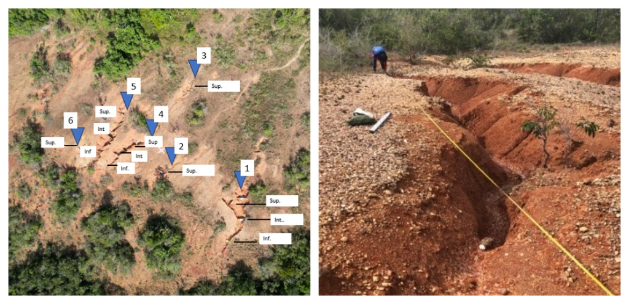

Figura 2: Feições de erosão linear no sítio experimental.

*Nota: Ortomosaico derivado de VANT mostrando a distribuição espacial das feições erosivas mapeadas e medição em campo dos parâmetros morfométricos (profundidade, largura e comprimento) em uma das feições erosivas ativas.*

Como parametrização preliminar do delineamento, os valores de $\gamma$ calculados para as seis feições inventariadas permanecem próximos da unidade sob cenários conservadores de $k_3$ e $n_3$ (Tabela 1), reforçando que o termo geotécnico será testado como vulnerabilidade potencial, e não como mecanismo dominante já estabelecido para o Plintossolo estudado.

Tabela 1. Parametrização preliminar de $\gamma$ para as seis feições erosivas em função de $k_3$ e $n_3$ hipotéticos

| Feição | Prof. (m) | $H/H_c$ | $\gamma$ ($k_3$=2, $n_3$=2) | $\gamma$ ($k_3$=5, $n_3$=2) | $\gamma$ ($k_3$=2, $n_3$=3) |
| --- | --- | --- | --- | --- | --- |
| F1 | 1,10 | 0,33 | 1,22 | 1,54 | 1,07 |
| F2 | 0,40 | 0,12 | 1,03 | 1,07 | 1,00 |
| F3 | 0,60 | 0,18 | 1,06 | 1,16 | 1,01 |
| F4 | 1,40 | 0,42 | 1,35 | 1,88 | 1,15 |
| F5 | 1,50 | 0,45 | 1,40 | 2,01 | 1,18 |
| F6 | 0,60 | 0,18 | 1,06 | 1,16 | 1,01 |

Tabela 2. Parametrização preliminar de $\alpha$ para três posições da vertente em função de $n_1$ hipotético

| Posição | VIB (cm/h) | $\alpha$ ($n_1$ = 0,5) | $\alpha$ ($n_1$ = 1,0) | $\alpha$ ($n_1$ = 1,5) |
| --- | --- | --- | --- | --- |
| Terço superior | 3,13 | 1,38 | 1,92 | 2,66 |
| Terço intermediário | 1,53 | 1,98 | 3,92 | 7,76 |
| Terço inferior | 1,59 | 1,94 | 3,77 | 7,33 |

Os parâmetros geotécnicos (coesão efetiva $c$ = 13,02 kPa, ângulo de atrito interno $\phi$ = 34,93° e peso específico saturado $\gamma_{sat}$ = 19,93 kN/m³) foram determinados por ensaio de cisalhamento direto (ASTM D3080) em amostras indeformadas extraídas do horizonte Bt sob condições saturadas. A erodibilidade $K_{RUSLE}$ = 0,035 t h MJ$^{-1}$ mm$^{-1}$ foi estimada a partir da distribuição granulométrica, teor de matéria orgânica, código de estrutura e classe de permeabilidade do horizonte superficial utilizando o nomograma padrão (Wischmeier, Johnson, e Cross 1971).

Dois sítios contrastantes (Latossolo e Argissolo) já foram pré-selecionados em campo na mesma região fisiográfica do sítio-alvo (Tabuleiros Costeiros de Sergipe), com base em levantamento pedológico prévio (Embrapa) e validação in situ por tradagem e ensaio expedito de infiltração. Os valores reportados na Tabela 3 para essas duas classes representam **prioris pedológicas** derivadas de medianas regionais (Silva et al. 2009; Bertoni e Lombardi Neto 2017) e serão substituídos pelas medições in situ antes do início do monitoramento, operando na fase atual como referência para dimensionamento experimental e elicitação de prioris bayesianas. O Latossolo opera como controle negativo ($\alpha \approx \beta \approx \gamma \approx 1$), representando solos bem drenados sem impedância hidráulica, toxicidade ou feições erosivas profundas, enquanto o Argissolo funciona como controle parcial, compartilhando impedância hidráulica moderada no horizonte Bt, porém sem plintita ou toxicidade extrema por alumínio. As propriedades das três classes são sumarizadas na Tabela 3.

Tabela 3. Propriedades das três classes de solo utilizadas no experimento (Plintossolo: medições in situ; Latossolo e Argissolo: prioris regionais, a substituir por medições antes do monitoramento).

| Propriedade | Plintossolo (medido em campo) | Latossolo (prior regional) | Argissolo (prior regional) |
| --- | --- | --- | --- |
| VIB superior (cm/h) | 3,13 | 12,0 | 4,5 |
| VIB intermediária (cm/h) | 1,53 | 9,0 | 2,5 |
| VIB inferior (cm/h) | 1,59 | 7,0 | 2,8 |
| $m_{Al}$ Ap (%) | 15,2 | 10,0 | 20,0 |
| $m_{Al}$ subsuperfície (%) | 84–99 | 20,0 | 45,0 |
| $c$ (kPa, saturado) | 13,02 | 30,0 | 18,0 |
| $\phi$ (°) | 34,93 | 30,0 | 32,0 |
| $\gamma_{sat}$ (kN/m³) | 19,93 | 18,0 | 19,0 |
| $H_c$ (m) | 3,35 | 5,77 | 4,33 |
| $H/H_c$ médio | 0,28 | 0,00 | 0,08 |
| $K_{RUSLE}$ (t h MJ$^{-1}$ mm$^{-1}$) | 0,035 | 0,015 | 0,025 |

*Nota: Os valores do Plintossolo foram obtidos de medições em campo; os valores do Latossolo e do Argissolo constituem prioris pedológicas derivadas de medianas regionais e serão substituídos pelos valores in situ após instalação dos sítios.*

## 5.2 Delineamento multi-classe

No arranjo multi-classe, o sítio-alvo (S1) será instalado no Plintossolo Háplico Distrófico descrito na seção 5.1, onde VIB varia de 3,13 cm/h no terço superior a 1,53 cm/h no intermediário, saturação por alumínio atinge 99,2% no horizonte BAc e seis feições erosivas com $H/H_c$ de 0,12–0,45 foram inventariadas. O sítio-controle negativo (S2) será instalado em Latossolo Vermelho-Amarelo Distrófico, preferencialmente na mesma região fisiográfica, selecionado por apresentar VIB tipicamente superior a 6 cm/h, saturação por alumínio inferior a 30%, espessura homogênea do horizonte Bw sem impedância hidráulica abrupta e ausência de feições erosivas lineares ativas. O sítio-controle parcial (S3) será instalado em Argissolo Vermelho-Amarelo Distrófico, com gradiente textural abrupto (horizonte Bt adensado) que reproduz impedância hidráulica similar à do Plintossolo, porém sem plintita e com saturação por alumínio intermediária (tipicamente 30–60%), constituindo classe que permitirá isolar o efeito do regime hidráulico ($\alpha$) das demais amplificações.

## 5.3 Parcelas de erosão e distribuição por sítio

[figure not shown]

Figura 3: Esquema do experimento de erosão. (a) Parcela padrão Wischmeier com divisor Geib, tanques de coleta e armazenamento de sedimentos e chapas galvanizadas de delimitação lateral. (b) Distribuição das parcelas nos três sítios pedológicos.

Espacialmente, a distribuição apresentada na Fig. Figura 3 organiza o contraste entre o sítio-alvo em Plintossolo e os dois sítios-controle, preservando comparabilidade geomorfológica suficiente para estimar separadamente as contribuições de $\alpha$, $\beta$ e $\gamma$.

Operacionalmente, o sistema de coleta com divisor Geib adotado em cada parcela é detalhado na Fig. Figura 4, em que o fracionamento do deflúvio excedente entre tanques amplia a capacidade de armazenamento sem perda de representatividade amostral (Melo Neto et al. 2021).

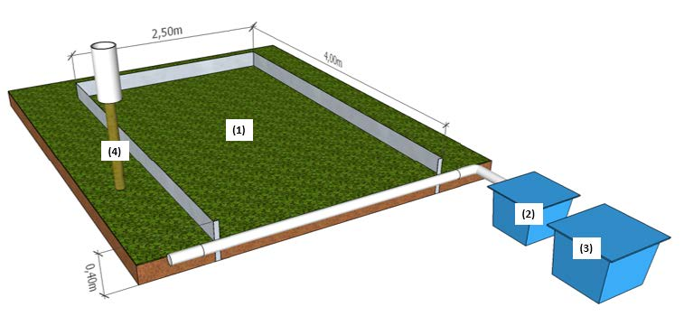

(a) Croqui da parcela com divisor Geib e tanques de coleta

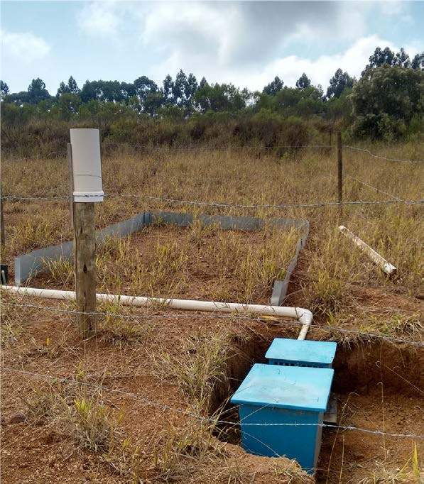

(b) Parcela instalada em campo

Figura 4: Parcela de monitoramento de erosão hídrica do solo com divisor Geib. (a) Croqui esquemático e (b) vista de campo. Adaptado de Melo Neto et al. (2021).

## 5.4 Protocolo de ensaios

### 5.4.1 Ensaios comuns às três classes

Em campo, o protocolo de monitoramento compreenderá quatro componentes simultâneos realizados durante dois anos hidrológicos consecutivos (abril a março), cobrindo a totalidade da estação chuvosa (abril–agosto) e o período seco (setembro–março). Em conformidade com a diretriz de instalação de campo mínima, a medição contínua de precipitação utilizará um único pluviógrafo de báscula (resolução 0,2 mm, intervalo de registro de 5 min) instalado em posição central aos três sítios, complementado por dados da estação meteorológica oficial mais próxima (INMET) para verificação de homogeneidade pluviométrica entre os sítios. Sempre que viável, a medição de alta resolução intra-evento (intensidade e energia cinética por classe de diâmetro de gota) será obtida em campanhas pontuais com disdrômetro a laser cedido em regime de empréstimo institucional, sem custo de locação ou aquisição. O índice de erosividade $R$ será calculado por evento como $EI_{30}$ na formulação original de Wischmeier e Smith (1978) e, em paralelo, pela energia cinética unitária adaptada às chuvas tropicais brasileiras de Lombardi Neto e Moldenhauer (1992), o que permite verificar a sensibilidade de $K_{obs}$ à escolha da equação de erosividade e fornece compatibilidade com o mapa de erosividade do Brasil (Oliveira, Wendland, e Nearing 2013). Eventos erosivos são definidos como aqueles com precipitação total $\geq$ 10 mm separados por intervalo seco mínimo de 6 h, conforme convenção consolidada na literatura. A coleta de sedimentos em tanques de armazenamento ocorrerá após cada evento, quantificando a perda de solo por parcela em t ha$^{-1}$ evento$^{-1}$. A VIB será medida sazonalmente por infiltrômetro de duplo anel cedido em regime de empréstimo institucional (3 posições × 2 repetições por sítio), e amostras de solo serão coletadas para determinação de análise de fertilidade de rotina (pH, Al³⁺, H+Al, CTC, V%, saturação por alumínio $m$) por serviço terceirizado de baixo custo, ao passo que granulometria completa, matéria orgânica, limites de Atterberg, densidade do solo e de partículas e mineralogia por difração de raios X (DRX) serão realizadas em parceria institucional com laboratórios multiusuários (Embrapa, IFBA, UFS e congeneres), sem custo direto para o projeto. O levantamento topográfico para determinação dos fatores $L$ e $S$ utilizará trena, nível óptico e clinômetro em cada parcela, dispensando equipamento de alta precisão.

Sob condição saturada, o ensaio de cisalhamento direto (tensões normais de 25, 50, 100 e 200 kPa) será realizado em parceria com laboratório de geotecnia conveniado, em amostras indeformadas do horizonte diagnóstico de cada classe (Fig. Figura 5), fornecendo coesão ($c$) e ângulo de atrito ($\phi$) para cálculo de $H_c$ pela Equação 9. A condutividade hidráulica saturada por horizonte (permeâmetro de carga constante) será determinada igualmente em parceria, em amostras indeformadas de dois a três horizontes por perfil, validando a presença ou ausência de impedância hidráulica abrupta.

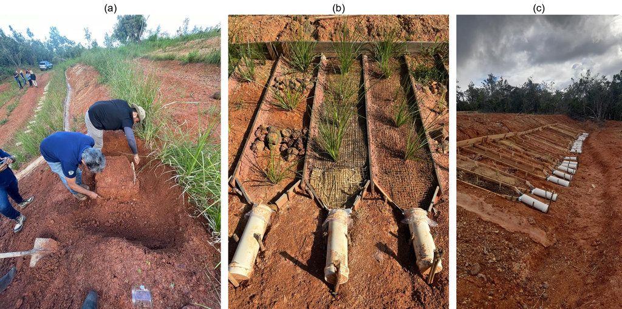

Figura 5: Elementos do sítio experimental em Plintossolo Háplico, Tabuleiros Costeiros de Sergipe. (a) Bloco indeformado extraído para ensaio de cisalhamento direto ($c$ = 13,02 kPa, $\phi$ = 34,93°). (b) Parcelas de coleta de sedimentos posicionadas na base do talude erosivo. (c) Vista geral do talude com feições erosivas ativas.

Complementarmente às parcelas Wischmeier, microparcelas instrumentadas (1 m² de área coletora) serão instaladas em uma posição representativa por sítio, em escala compatível com a diretriz de instalação de campo mínima, e equipadas com pluviómetro simples; a captura da distribuição intra-evento da intensidade e da energia cinética da chuva por classe de diâmetro de gota será obtida em campanhas pontuais com disdrômetro a laser cedido em regime de empréstimo institucional, em janelas centradas nos eventos previstos como mais energéticos da estação chuvosa. A conectividade hidrossedimentológica em Plintossolos depende fortemente de pulsos intensos cuja duração raramente excede 15 min, de modo que a resolução padrão de 5 min pode subestimar picos de intensidade que disparam escoamento hortoniano e destacamento por impacto de gotas no horizonte BAc (Kinnell 2005). As campanhas com disdrômetro fornecerão observações de alta frequência que alimentarão diretamente o modelo de mistura da Equação 3, pois a energia cinética acumulada por evento constitui a variável de entrada para estimativa da energia de desagregação específica ($E_d$) e calibração dos coeficientes $a_1$–$a_4$.

Sessões de chuva simulada em laboratório complementarão o monitoramento de campo, executadas em parceria institucional com simulador de chuva já disponível em laboratório conveniado, replicando os quantis superiores da distribuição de intensidade observada (intensidades correspondentes aos percentis 90, 95 e 99 da série pluviográfica do sítio) sobre amostras indeformadas de cada horizonte diagnóstico, em condição natural e após tratamento com ditionito-citrato-bicarbonato para remoção seletiva de ferro livre. O simulador de chuva operará com bicos oscilantes a 3 m de altura, produzindo gotas com distribuição de tamanho e energia cinética comparáveis à chuva natural tropical (intensidades de 30, 60, 90 e 120 mm/h, duração de 30 min por intensidade). A comparação entre amostras naturais e desferrificadas permitirá estimar a fração dispersável ($f_d$) e a energia de desagregação ($E_d$) para cada classe de solo, calibrando os parâmetros do modelo de mistura sob condições controladas antes de aplicá-los aos dados de campo (Fig. Figura 6).

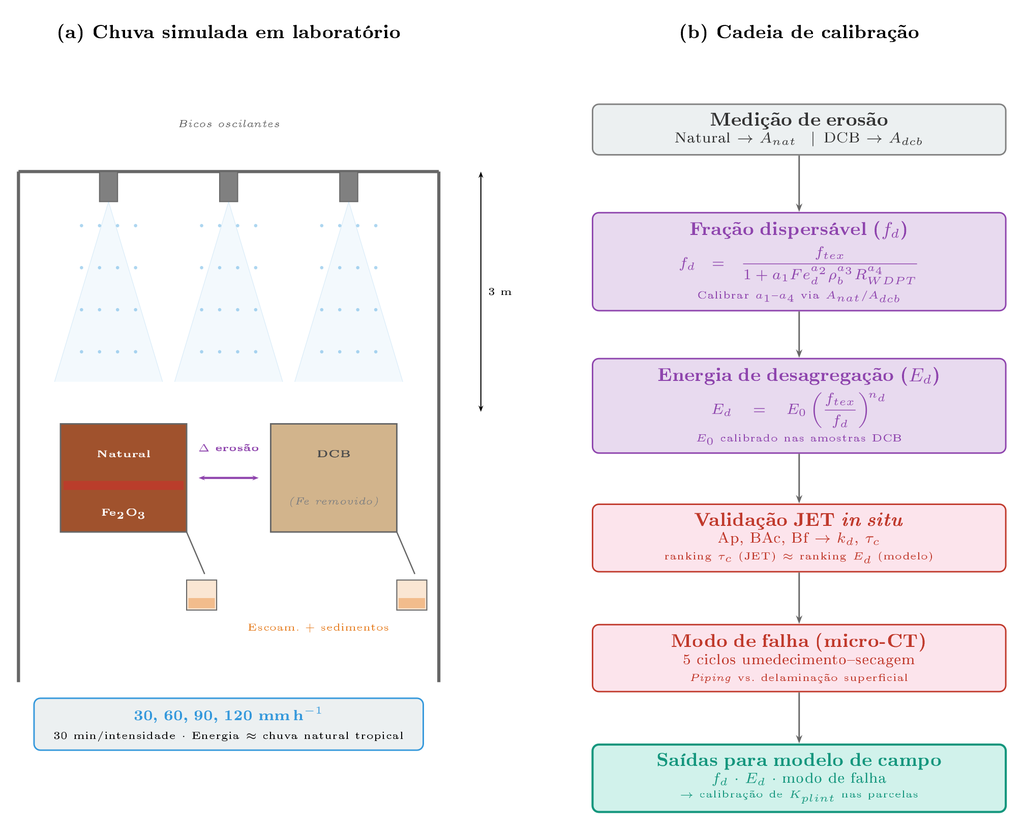

Figura 6: Configuração do ensaio de chuva simulada e cadeia de calibração. (a) Estrutura laboratorial com bicos oscilantes a 3 m de altura, amostras naturais e tratadas com DCB, e coleta de escoamento e sedimentos sob quatro intensidades (30–120 mm h$^{-1}$). (b) Cadeia de calibração desde a medição de erosão até a saída para o modelo de campo, passando pela fração dispersável ($f_d$), energia de desagregação ($E_d$), validação JET e modo de falha por microtomografia.

### 5.4.2 Ensaios específicos por classe

No sítio S1 (Plintossolo), o monitoramento de profundidade das feições adjacentes às parcelas utilizará pinos de erosão (20 pinos por feição, espaçamento de 1 m longitudinal × 0,5 m transversal, leituras quinzenais), para separar incremento volumétrico associado à incisão vertical e à instabilidade lateral potencial. A parcela com horizonte BAc exposto por escavação controlada permitirá isolar o efeito da toxicidade extrema ($m$ = 99,2%) sobre a erodibilidade observada. Um inventário completo das feições erosivas (profundidade, largura, comprimento, $H/H_c$) será realizado semestralmente.

Para elucidar o modo de falha do material cimentado, ensaios de Jet Erosion Test (JET) invertido serão realizados in situ nos taludes das feições F1, F4 e F5, que apresentam os maiores valores de $H/H_c$, com jatos aplicados em três horizontes distintos (Ap, BAc e Bf) para determinação do coeficiente de erodibilidade do solo ao jato ($k_d$, cm³ N$^{-1}$ s$^{-1}$) e da tensão cisalhante crítica ($\tau_c$, Pa) em cada camada (Hanson e Cook 2004). O equipamento JET será cedido em regime de empréstimo institucional por laboratório conveniado, sem custo de locação, e a execução in situ nas três feições foi previamente autorizada pelo proprietário da área, conforme termo de anuência arquivado junto à documentação do projeto, autorização que abrange a abertura de janelas de inspeção subverticais e a recomposição posterior do talude com material local. A combinação dos parâmetros JET com a fração dispersável ($f_d$) estimada pelo modelo de mistura da Equação 3 permitirá verificar se a resistência ao cisalhamento do material cimentado é consistente com a predição do modelo mecanístico, fechando a cadeia causal entre mineralogía dos óxidos, cimentação e erodibilidade efetiva.

Complementarmente, amostras indeformadas extraídas com caixa metálica (15 × 15 × 30 cm) dos mesmos horizontes serão submetidas a tomografia computadorizada de raios X (micro-CT, resolução de 50 µm) em parceria com laboratório multiusuário (a confirmar por carta de anuência previamente à submissão), antes e após ciclos controlados de umedecimento e secagem (5 ciclos, saturação por capilaridade seguida de secagem a 40 °C por 48 h). A tomografia fornecerá perfil vertical tridimensional da progressão da ruptura, permitindo distinguir se o colapso da matriz cimentada se dá predominantemente por piping (desenvolvimento de canais internos ao longo de macroporos obstruídos por óxidos) ou por delaminação superficial (destacamento laminar progressivo da crosta ferruginosa), informação relevante para a escolha de práticas de manejo e para a interpretação física do expoente $n_d$ do modelo de energia de desagregação (Equação 4). A fração de porosidade conectada e o diâmetro médio de poros antes e após os ciclos constituirão variáveis auxiliares para validação do modelo de mistura em condições de campo. A formalização do convênio com laboratório multiusuário de micro-CT será conduzida ativamente nas etapas iniciais do projeto, com prospecção de no mínimo duas instituições parceiras para mitigar o risco de indisponibilidade pontual de equipamento.

Em escala de vertente, o rastreamento da evolução das feições erosivas será realizado por medições diretas em campo (trena, nível óptico e baliza graduada) em transectos fixos a cada campanha bimestral, complementadas por registro fotográfico padronizado a partir de pontos fixos georreferenciados, e, sempre que disponíveis, por levantamentos com drone cedido em regime de empréstimo institucional ou em parceria com grupos de pesquisa locais (sem custo de aquisição ou locação de equipamento). A diferenciação temporal entre seções transversais consecutivas (limiar de detecção de mudança de ±5 cm) quantificará o alongamento linear, o recuo de cabeceira e a variação volumétrica de cada feição ao longo do período experimental, permitindo correlacionar a taxa de progressão das feições com a integral temporal da energia de escoamento concentrado acumulada entre campanhas, vinculando diretamente o fator $K_{plint}$ recalibrado ao desempenho hidrossedimentológico observado em escala de vertente.

No sítio S2 (Latossolo), não se preveem pinos de erosão nem parcelas com horizonte exposto, dado que a hipótese H5 prediz $\delta \approx 1{,}0$ (ausência de amplificação). A mineralogia por DRX confirmará a presença de gibbsita e oxi-hidróxidos de ferro responsáveis pela microagregação estável típica de Latossolos (Silva et al. 2009).

No sítio S3 (Argissolo), pinos de erosão serão instalados apenas se feições erosivas lineares forem identificadas durante o inventário inicial. Uma parcela com horizonte Bt exposto permitirá avaliar se a impedância hidráulica do gradiente textural abrupto, sem toxicidade extrema por alumínio, é suficiente para gerar $\alpha > 1$ isoladamente.

## 5.5 Cálculo de $K_{obs}$

Para cada parcela em solo nu ($C = P = 1$), $K_{obs}$ será obtido por inversão da Equação 1 (Equação 12).

$$K_{obs} = \dfrac{A_{obs}}{R \times L \times S}
\tag{12}$$

Para o mesmo material, o fator $K_{RUSLE}$ será estimado pela Equação 2 a partir dos dados de granulometria, matéria orgânica e classificação de estrutura e permeabilidade do horizonte exposto. Como verificação de robustez frente às limitações reconhecidas do nomograma para solos tropicais (Alewell et al. 2019), $K_{RUSLE}$ será também estimado por dois preditores alternativos: a equação EPIC de Williams (1995), baseada em frações texturais e teor de carbono orgânico, e a equação de Torri, Poesen, e Borselli (1997), calibrada em escala global para uma gama mais ampla de classes pedológicas. A razão $\delta$ será reportada para os três estimadores, tomando o nomograma como referência primária e os demais como controles de sensibilidade quanto à escolha do estimador basal. A razão $\delta = K_{obs}/K_{RUSLE}$ quantificará a discrepância entre erodibilidade observada e prevista, que constitui a variável-resposta do modelo de correção.

## 5.6 Procedimento de calibração

Os cinco parâmetros livres ($n_1$, $\beta_{max}$, $k_2$, $k_3$, $n_3$) serão calibrados por protocolo sequencial em cinco etapas, explorando a estrutura multi-classe para isolar cada termo.

Sinteticamente, a Fig. Figura 7 reúne a sequência operacional da calibração e a articulação entre o modelo multiplicativo e o submodelo laboratorial auxiliar.

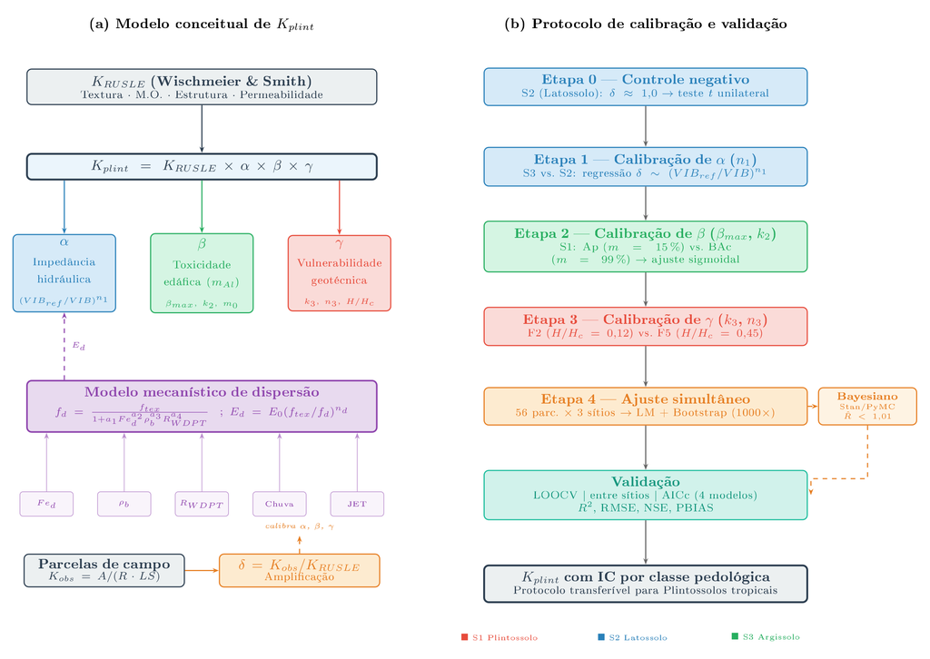

Figura 7: Estrutura conceitual e protocolo de calibração do modelo $K_{plint}$. (a) Arquitetura multiplicativa do fator de correção com os três mecanismos amplificadores ($\alpha$, $\beta$, $\gamma$), modelo mecanístico de dispersão e variáveis de entrada. (b) Protocolo de calibração sequencial em cinco etapas, com braço bayesiano hierárquico e validação cruzada entre sítios.

A calibração parte do Latossolo porque essa classe funciona como referência de adequação do nomograma. Se $\delta_{S2}$ permanecer próximo de 1{,}0, a discrepância observada nos demais sítios será atribuída às propriedades diagnósticas que diferenciam Argissolo e Plintossolo; caso contrário, os parâmetros ajustados para S1 e S3 serão interpretados em relação ao comportamento empírico do Latossolo, e não como correções absolutas. A partir desse ponto de ancoragem, o contraste entre Argissolo e Latossolo permite estimar a fração da amplificação associada ao rebaixamento de VIB, pois S3 combina $\alpha > 1$ com $\beta \approx 1$ e $\gamma \approx 1$, enquanto S2 tende a operar com $\alpha \approx 1$.

Uma vez definido o efeito hidráulico de referência, a calibração de $\beta$ será conduzida pelo contraste interno do Plintossolo entre parcelas com Ap preservado ($m$ = 15,2%) e BAc exposto ($m$ = 99,2%), mantidas sob VIB e declividade comparáveis. A diferença residual de $\delta$, após descontado o efeito de $\alpha$, será atribuída à toxicidade edáfica, com verificação externa pelo confronto entre o Bt exposto do Argissolo ($m$ intermediário) e o BAc exposto do Plintossolo ($m$ extremo). Esse arranjo evita que o efeito de alumínio seja confundido com o simples contraste de classe de solo.

A contribuição geotécnica será estimada apenas após estabilizar os termos hidráulico e edáfico. Nas parcelas de S1 adjacentes às feições F2 e F5, cujas razões $H/H_c$ contrastam de 0,12 a 0,45, a perda total de solo, somando parcela e pinos de erosão, será usada para calcular $\delta_{residual} = \delta_{obs} / (\alpha \times \beta)$. Esse resíduo representa a parcela de amplificação associada à aproximação do limiar de ruptura. Em seguida, todos os valores de $\delta_{obs}$ disponíveis nos três sítios, gerados pela combinação das seis parcelas com a replicação temporal por evento (estimativa de 60–120 observações independentes ao longo dos dois anos hidrológicos), serão integrados em um ajuste conjunto, partindo das estimativas marginais para obter um conjunto único de parâmetros capaz de representar simultaneamente os mecanismos hidráulico, edáfico e geotécnico.

## 5.7 Validação

A validação será conduzida em três escalas articuladas. A validação interna verificará a estabilidade paramétrica dentro do conjunto de calibração; a validação cruzada entre sítios testará a transferência do fator de correção entre classes pedológicas; e a validação externa, em fase posterior, exigirá aplicação do protocolo em pelo menos um sítio adicional com Plintossolo de características contrastantes, preferencialmente na Amazônia Oriental (Pará ou Maranhão) ou nos Tabuleiros Costeiros da Bahia.

## 5.8 Análises estatísticas

Em todas as análises, a razão $\delta = K_{obs}/K_{RUSLE}$ será tomada como variável-resposta, representando a amplificação da erodibilidade observada em relação ao valor previsto pelo nomograma. O Latossolo fornece o teste de referência dessa razão: $\delta_{S2}$ será confrontado com a unidade por teste t unilateral ($\alpha$ = 0,05), verificando se essa classe permanece dentro do domínio de adequação da USLE/RUSLE antes de se atribuir a amplificação dos demais sítios aos mecanismos propostos.

A estimação marginal seguirá a lógica causal estabelecida no protocolo de calibração. O termo hidráulico $\alpha$ será ajustado por regressão não linear univariada de $\delta_{S3}/\delta_{S2}$ contra $VIB_{ref}/VIB_{local}$; em seguida, $\beta$ será estimado pela forma sigmoidal da Equação 7 a partir do contraste entre Ap e BAc no Plintossolo, com verificação complementar entre Bt exposto no Argissolo e BAc exposto no Plintossolo; sobre esse resíduo hidropedológico já controlado, $\gamma$ será estimado por regressão não linear de $\delta_{residual} = \delta_{obs}/(\alpha \times \beta)$ contra $H/H_c$ nas feições F2 e F5. Esse encadeamento reduz a chance de que um parâmetro absorva artificialmente o efeito de outro.

A sensibilidade dos parâmetros à escolha das prioris será verificada por análise de robustez usando prioris difusas (Uniforme em intervalos amplos) e prioris contrárias (centradas em valores extremos da literatura). Como preditores hierárquicos de segundo nível, $I_{max,15}$ e $E_k$ condicionarão a distribuição a posteriori de $n_1$ e $n_d$, reduzindo extrapolação para regimes pluviométricos não observados. A implementação utilizará Stan ou PyMC com quatro cadeias de 5000 iterações, descartando as primeiras 1000 como aquecimento, e adotará $\hat{R}$ < 1,01 e tamanho efetivo de amostra > 400 como critérios de convergência (Gelman et al. 2013).

Sob perspectiva preditiva, o desempenho do modelo será avaliado por validação cruzada leave-one-out sobre o conjunto total de observações e por validação cruzada entre sítios, calibrando-se o modelo com dados de dois sítios e testando-o no terceiro. O desempenho será quantificado por $r^2$, RMSE, NSE, KGE e PBIAS (Equações 13 a 17).

A superioridade do modelo multiplicativo será avaliada por Critério de Informação de Akaike corrigido (AICc), comparando-se $K_{RUSLE}$ isolado, modelo aditivo, modelo multiplicativo parcial com apenas $\alpha$ e modelo multiplicativo completo. A comparação entre o modelo bayesiano hierárquico e o modelo frequentista será feita por WAIC, enquanto a hipótese de especificidade pedológica será examinada por ANOVA de $\delta$ entre as três classes de solo, seguida de contrastes ortogonais entre Plintossolo, Latossolo e Argissolo.

Quanto a benchmarks externos baseados em processo, a perda de solo prevista pelo modelo $K_{plint}$ inserida na estrutura USLE/RUSLE será confrontada com simulações independentes do WEPP-Hillslope (Flanagan e Nearing 1995) e do Morgan-Morgan-Finney revisado (MMF) (Morgan 2001), parametrizados a partir das mesmas variáveis de campo (granulometria, matéria orgânica, condutividade hidráulica saturada, coesão e ângulo de atrito) e da mesma série pluviográfica de alta resolução.

Essa confrontação permite verificar se a amplificação capturada por $\delta$ na formulação empírica corrigida é coerente com a perda predita por modelos de base física que resolvem explicitamente infiltração, escoamento e destacamento; convergência entre as três abordagens reforça a interpretabilidade mecanística dos termos $\alpha$, $\beta$ e $\gamma$, ao passo que divergências sistemáticas indicarão limites de aplicabilidade da estrutura multiplicativa e direcionarão revisão do submodelo correspondente.

$$r^2 = \left(\dfrac{\sum (K_{obs,i} - \bar{K}_{obs})\,(K_{pred,i} - \bar{K}_{pred})}{\sqrt{\sum (K_{obs,i} - \bar{K}_{obs})^2}\,\sqrt{\sum (K_{pred,i} - \bar{K}_{pred})^2}}\right)^2
\tag{13}$$

$$RMSE = \sqrt{\dfrac{1}{n}\sum_{i=1}^{n}(K_{obs,i} - K_{pred,i})^2}
\tag{14}$$

$$NSE = 1 - \dfrac{\sum(K_{obs,i} - K_{pred,i})^2}{\sum(K_{obs,i} - \bar{K}_{obs})^2}
\tag{15}$$

$$KGE = 1 - \sqrt{(r-1)^2 + \left(\dfrac{\sigma_{pred}}{\sigma_{obs}}-1\right)^2 + \left(\dfrac{\bar{K}_{pred}}{\bar{K}_{obs}}-1\right)^2}
\tag{16}$$

$$PBIAS = \dfrac{\sum(K_{obs,i} - K_{pred,i})}{\sum K_{obs,i}} \times 100
\tag{17}$$

A distinção entre $r^2$ (coeficiente de Pearson ao quadrado, sensível apenas à correlação) e $NSE$ (sensível também a viés e variância) é mantida para evitar a equivalência espúria que ocorreria se $R^2$ fosse definido pela soma de quadrados dos resíduos, formulação na qual $R^2 \equiv NSE$ e a métrica perde poder discriminante (Gupta et al. 2009). O $KGE$ (Equação 16) é incluído como métrica complementar por decompor a aderência em correlação ($r$), razão de variabilidade ($\sigma_{pred}/\sigma_{obs}$) e razão de viés ($\bar{K}_{pred}/\bar{K}_{obs}$), permitindo diagnosticar separadamente cada modo de falha do modelo (Knoben, Freer, e Woods 2019).

## 5.9 Análise de sensibilidade global e identificabilidade

Quanto à robustez paramétrica, a calibração será acompanhada de análise de sensibilidade global por dois métodos complementares. Os índices elementares de Morris (efeitos elementares com $r$ = 50 trajetórias) serão computados como triagem inicial para descartar parâmetros de efeito desprezível sobre $\delta$, e a decomposição de variância de Sobol (índices de primeira ordem $S_i$ e totais $S_{T_i}$, com $N$ = 4096 amostras quasi-Monte Carlo) quantificará a contribuição relativa de cada parâmetro à variância da saída do modelo, incluindo interações de ordem superior (Saltelli et al. 2010). A identificabilidade empírica dos cinco parâmetros livres será verificada pela matriz de correlação a posteriori e pelo perfil de verossimilhança, sinalizando colinearidade quando $|\rho_{ij}| > 0{,}9$ ou quando o perfil for praticamente plano em um intervalo amplo. Os limiares fixados a priori ($VIB_{ref}$ = 6 cm/h, $m_0$ = 50% e fator de segurança FS = 1,5 sobre $H_{c,\text{máx}}$) serão submetidos a varredura paramétrica nos intervalos $VIB_{ref} \in [4,\,8]$ cm/h, $m_0 \in [30,\,70]$% e $\text{FS} \in [1{,}0,\,2{,}0]$, reportando-se o impacto sobre $R^2$, NSE, KGE e sobre os parâmetros estimados, de modo a documentar a sensibilidade do modelo a essas escolhas e evitar interpretação espúria de parâmetros calibrados sob limiares discutíveis.

Na avaliação de equifinalidade, a metodologia GLUE (Generalized Likelihood Uncertainty Estimation) será aplicada com 50.000 simulações de Monte Carlo amostradas das prioris fracamente informativas, retendo o conjunto de parâmetros que produz NSE > 0,5 e mapeando a região de comportamento aceitável no espaço de parâmetros (Beven e Binley 2014). A presença de múltiplas regiões desconectadas indicará equifinalidade preocupante e exigirá revisão estrutural; uma região convexa única suportará a interpretabilidade física dos parâmetros.

No dimensionamento amostral, análise de poder a priori realizada por simulação paramétrica indica que, para detectar com poder estatístico de 0,80 ($\alpha$ = 0,05) uma razão $\delta_{S1}/\delta_{S2}$ = 2,0 com coeficiente de variação intra-sítio de 30% (compatível com a literatura de erosividade em parcelas Wischmeier tropicais), são necessários pelo menos 18 valores de $\delta_{obs}$ por sítio. No desenho proposto, as duas parcelas por sítio combinadas à replicação temporal por evento ao longo de dois anos hidrológicos (estimativa de 20–40 eventos erosivos por sítio) atingem essa condição sob conservação do número de eventos previstos, sob a ressalva de que a perda de replicação espacial reduz a capacidade de separar variação intra-vertente de variação entre sítios. Para detecção de efeito menor ($\delta = 1{,}5$), o poder cai para 0,55, o que justifica a interpretação conservadora dos resultados quando a amplificação observada for moderada e reforça a necessidade de validar o protocolo em sítios adicionais em fase posterior, conforme previsto na seção de validação.

## 5.10 Riscos, pré-registro e dados abertos

Os principais riscos do protocolo incluem uma estação chuvosa anomalamente seca durante os dois anos de monitoramento, o destacamento de chapas de delimitação nas parcelas em terraços de alta declividade, a redistribuição lateral de água subsuperficial entre parcelas adjacentes em sítios com gradiente textural marcado, a impossibilidade de instalar parcela com horizonte BAc exposto sob saturações por alumínio extremas quando a remoção do horizonte Ap induzir compactação não representativa e a ocorrência de instabilidade geotécnica fora dos limites das parcelas, conforme apontado nos pressupostos. Para cada risco, registra-se o procedimento de mitigação na Tabela 4 e o critério formal de descontinuidade do braço experimental afetado.

Tabela 4. Registro de riscos e mitigações do protocolo experimental.

[output not shown]

A hipótese principal, a estrutura do modelo, os parâmetros a calibrar, os limiares fixados a priori e os critérios de aceitação serão registrados em plataforma pública de pré-registro (Open Science Framework) antes do início da coleta de campo, conforme recomendado para estudos de modelagem ambiental com elevada flexibilidade analítica (Nosek et al. 2018). Os dados brutos de pluviografia, perda de solo por evento, propriedades de solo, JET e fotogrametria, bem como o código de calibração (Python/Stan), serão disponibilizados em repositório com DOI (Zenodo) sob licença CC-BY 4.0, em conformidade com os princípios FAIR (Findable, Accessible, Interoperable, Reusable) (Wilkinson et al. 2016). As autorizações de coleta e instalação em áreas privadas ou unidades de conservação serão obtidas previamente nas instâncias competentes (proprietários e órgãos ambientais estaduais).

## 5.11 Orçamento preliminar do projeto

Em coerência com a diretriz operacional de instalação de campo mínima e execução em parceria institucional, o orçamento foi reduzido aos itens estritamente indispensáveis que exigem custeio direto, isto é, a infraestrutura básica das parcelas Wischmeier, os insumos de amostragem indeformada e a análise química de rotina necessária à caracterização inicial do complexo sortivo. Todos os demais componentes do protocolo, a saber, granulometria completa, mineralogia por DRX, limites de Atterberg, densidade, ferro livre por DCB, hidrofobicidade pós-secagem, condutividade hidráulica saturada, cisalhamento direto, chuva simulada, Jet Erosion Test invertido e microtomografia de raios X, bem como o uso pontual de disdrômetro a laser, infiltrômetro de duplo anel, pluviógrafo de báscula e drone, serão executados em parceria institucional com laboratórios multiusuários (Embrapa, IFBA, UFS e congêneres) ou mediante empréstimo institucional de equipamento, sem custo direto para o projeto. As cartas de anuência das instituições parceiras serão anexadas à submissão. Os valores representam preços médios de planejamento para 2026 e devem ser confirmados por cotação formal antes da execução financeira.

Tabela 5. Orçamento mínimo viável para dois anos hidrológicos de monitoramento, em regime de execução por parceria institucional.

| Grupo | Item | Quantidade | Valor unitário (R$) \| Subtotal (R$) | Observação |  |
| --- | --- | --- | --- | --- | --- |
| Infraestrutura de campo | Parcelas Wischmeier completas (chapas galvanizadas, calha/divisor Geib, tanques e instalação) | 6 | 4.500 | 27.000 | Material metálico, reservatórios e mão de obra local |
| Infraestrutura de campo | Microparcelas coletoras de 1 m² (uma por sítio) | 3 | 900 | 2.700 | Estrutura PVC/metálica e reservatório auxiliar |
| Infraestrutura de campo | Pinos de erosão, marcos e sinalização das feições | 1 lote | 2.500 | 2.500 | Malha de pinos para F1–F6 e reposição |
| Amostragem | Caixas metálicas, anéis volumétricos e insumos de amostragem indeformada | 1 lote | 6.000 | 6.000 | Coleta de blocos, anéis e acondicionamento |
| Análises de rotina | Análise de fertilidade básica (pH, Al³⁺, H+Al, CTC, V%, $m$%) | 1 lote | 500 | 500 | Caracterização inicial do complexo sortivo dos três sítios |
| **Total estimado — orçamento mínimo viável** |  |  |  | **38.700** |  |
| **Itens executados em parceria institucional (sem custo direto)** |  |  |  |  |  |
| Instrumentação cedida em empréstimo | Pluviógrafo de báscula, disdrômetro a laser, infiltrômetro de duplo anel, drone para fotogrametria | — | — | parceria | Empréstimo institucional pontual |
| Análises laboratoriais em parceria | Granulometria completa, matéria orgânica, limites de Atterberg, densidade, DRX, ferro livre por DCB, hidrofobicidade (WDPT), condutividade hidráulica saturada | — | — | parceria | Laboratórios multiusuários conveniados |
| Geotecnia em parceria | Cisalhamento direto saturado | — | — | parceria | Laboratório de geotecnia conveniado |
| Ensaios especiais em parceria | Chuva simulada em laboratório, Jet Erosion Test invertido, microtomografia de raios X (micro-CT) | — | — | parceria | Convênio com laboratórios especializados |
| Modelagem e curadoria | Calibração frequentista e bayesiana, análise GLUE/Sobol, pré-registro OSF e depósito Zenodo, redação e revisão | — | — | tempo do pesquisador | Atividades absorvidas pela equipe própria do projeto |

O orçamento mínimo viável de R$ 38.700 cobre exclusivamente os itens cuja execução depende de aquisição direta (estruturas físicas das parcelas, insumos de amostragem indeformada e análise química de rotina). A integralidade dos demais componentes laboratoriais e instrumentais é viabilizada por convênios e empréstimos institucionais, modalidade que reduz a barreira financeira de submissão sem comprometer a estrutura metodológica multi-classe nem a separabilidade dos termos $\alpha$, $\beta$ e $\gamma$. As parcerias para micro-CT e para fotogrametria com drone serão prospectadas em paralelo junto a, no mínimo, duas instituições por modalidade, garantindo redundância operacional e preservando integralmente a resolução tridimensional da progressão de ruptura e o monitoramento topográfico bimestral previstos no protocolo.

# 6 Resultados esperados e contribuição

Espera-se, nos três sítios contrastantes, gradiente de resposta compatível com o mecanismo dominante de cada classe de solo. No sítio S2 (Latossolo), a erodibilidade observada pode situar-se próxima à prevista pelo nomograma ($\delta \approx 1{,}0$), confirmando que a microagregação estável por oxi-hidróxidos compensa parcialmente a elevação de $M$ pela granulometria argilosa (Silva et al. 2009). No sítio S3 (Argissolo), o gradiente textural abrupto pode gerar amplificação moderada ($\delta \approx 1{,}5$–2,0), atribuível predominantemente ao fator $\alpha$ sob VIB reduzida pela impedância do horizonte Bt, com contribuição limitada de $\beta$ e $\gamma$. No sítio S1 (Plintossolo), a erodibilidade observada no terço intermediário (VIB = 1,53 cm/h) pode exceder a prevista pelo nomograma em fator de 2 a 4, indicando subestimativa sistemática do $K$ em regime de escoamento hortoniano com toxicidade extrema.

Para os parâmetros, o expoente $n_1$ situa-se provavelmente na faixa 0,5–1,5, com valores mais elevados correspondendo a maior sensibilidade do sistema à VIB. O fator $\beta_{max}$ é esperado na faixa 1,5–3,0, refletindo a amplificação pela supressão de cobertura em horizontes com toxicidade extrema por alumínio. O parâmetro $k_3$ do fator geotécnico permanece o mais incerto, pois depende da frequência e magnitude dos colapsos de talude durante o período experimental, sendo esperados valores baixos ($k_3$ = 1–3) se os colapsos forem episódicos e elevados ($k_3$ = 5–10) se a estação chuvosa desencadear múltiplos eventos de ruptura.

Metodologicamente, a principal contribuição consiste em estabelecer um protocolo multi-classe replicável para quantificar a discrepância entre $K_{RUSLE}$ e erodibilidade efetiva em solos tropicais com erosão linear, com validação cruzada entre classes pedológicas e identificação de quais dos três mecanismos, regime hidráulico, toxicidade e geotécnica, contribuem de modo preponderante para essa discrepância. A incorporação do modelo mecanístico de dispersão baseado em fração de ferro livre, densidade aparente e hidrofobicidade pós-secagem (Equação 3 e Equação 4) desloca a proposta de uma adaptação empírica local para um protocolo transferível com interpretabilidade física, pois a cadeia causal que conecta cimentação ferruginosa, fração dispersável e energia de desagregação independe do sítio específico e pode ser recalibrada para Plintossolos de outras regiões fisiográficas, como Amazônia Oriental, Cerrado e Tabuleiros Costeiros da Bahia, sem reestruturação do modelo.

A instrumentação de alta frequência mobilizada por meio de parcerias institucionais, com disdrômetro a laser, microparcelas e micro-CT, combinada à modelagem hierárquica bayesiana, amplia a relevância do protocolo ao permitir que novos sítios sejam incorporados progressivamente à base de calibração, atualizando as distribuições a posteriori dos parâmetros com coerência em relação à evidência acumulada e reduzindo o risco de extrapolação para regimes pluviométricos não amostrados.

Operacionalmente, o protocolo oferece aos gestores de áreas degradadas um fator de correção que pode ser aplicado com dados de campo rotineiros, como VIB, análise de solo e profundidade de feição, para melhorar a estimativa de perda de solo em vertentes onde a USLE convencional subestima a erosão, enquanto os ensaios JET e a tomografia de raios X esclarecem o modo de falha dominante do material cimentado e podem orientar a seleção de práticas de bioengenharia de solos em função do mecanismo de ruptura identificado.

# 7 Pressupostos e limitações

A interpretação física dos parâmetros calibrados depende de pressupostos que precisam ser tratados como condições de validade, e não como garantias do modelo. A variação de VIB ao longo da vertente deve permanecer suficientemente estável entre eventos e estações para que $\alpha$ represente impedância hidráulica, e não apenas compactação transitória ou recuperação estrutural sazonal; por isso, o monitoramento sazonal de VIB é parte do controle de qualidade do protocolo. Do mesmo modo, a saturação por alumínio do horizonte efetivamente exposto precisa ser o principal condicionante da supressão de cobertura para que $\beta$ seja separável do fator $C$; em áreas onde sombreamento, tráfego animal ou manejo recente controlam a cobertura, essa separação torna-se menos identificável.

O fator $\gamma$ exige que a contribuição de instabilidade lateral ocorra dentro ou imediatamente adjacente à parcela monitorada. Se a mobilização volumétrica se concentrar a montante da unidade coletora, a perda medida subestimará a componente geotécnica e deslocará parte da variação para o erro residual. A própria estrutura multiplicativa também depende de independência operacional entre $\alpha$, $\beta$ e $\gamma$, condição que pode ser enfraquecida quando a mesma causa física, como compactação, alternância sazonal de umidade ou mudança estrutural do horizonte, reduz simultaneamente VIB e resistência ao cisalhamento.

A robustez temporal e espacial constitui a última condição de validade. Dois anos hidrológicos só fornecem base adequada para calibração se incluírem eventos capazes de acionar os processos dominantes, especialmente os pulsos de alta intensidade e os episódios de instabilidade de taludes. Além disso, os três sítios precisam compartilhar zona climática e faixa de declividade comparáveis, de modo que diferenças de $\delta$ sejam atribuíveis às propriedades do solo, e não a covariáveis externas. A pré-seleção dos sítios nos Tabuleiros Costeiros reduz esse risco, mas não elimina a necessidade de validação externa em outra unidade fisiográfica.

# 8 Referências

Alewell, Christine, Pasquale Borrelli, Katrin Meusburger, e Panos Panagos. 2019. “Using the USLE: chances, challenges and limitations of soil erosion modelling”. *International Soil and Water Conservation Research* 7 (3): 203–25. https://doi.org/10.1016/j.iswcr.2019.05.004.

Benavidez, R, B Jackson, D Maxwell, e K Norton. 2018. “A review of the (Revised) Universal Soil Loss Equation ((R)USLE): with a view to increasing its global applicability and improving soil loss estimates”. *Hydrology and Earth System Sciences* 22 (11): 6059–86. https://doi.org/10.5194/hess-22-6059-2018.

Bertoni, J, e F Lombardi Neto. 2017. *Conservação do solo*. 10º ed. São Paulo: Ícone Editora.

Beven, Keith, e Andrew Binley. 2014. “GLUE: 20 years on”. *Hydrological Processes* 28 (24): 5897–5918. https://doi.org/10.1002/hyp.10082.

Cassol, Cleidimar João et al. 2023. “Natural fertility and intrinsic fragility of soils in the Brazilian Cerrado”. *Revista em Agronegócio e Meio Ambiente* 16 (2): 1–22.

Craig, R. F. 2004. *Craig’s Soil Mechanics*. 7º ed. London; New York: Spon Press.

De Roo, A. P. J., e H.Th. Riezebos. 1992. “Infiltration experiments on loess soils and their implications for modelling surface runoff and soil erosion”. *CATENA*. https://doi.org/10.1016/0341-8162(92)90026-8.

Empresa Brasileira de Pesquisa Agropecuária. 2018. *Sistema Brasileiro de Classificação de Solos*. 5º ed. Brasília: Embrapa.

Flanagan, D. C., e M. A. Nearing. 1995. “USDA Water Erosion Prediction Project (WEPP): Hillslope Profile and Watershed Model Documentation”. NSERL Report 10. West Lafayette, IN, USA: USDA-ARS National Soil Erosion Research Laboratory.

Fredlund, Delwyn G., e Harianto Rahardjo. 1993. *Soil mechanics for unsaturated soils*. New York: John Wiley & Sons.

Gelman, Andrew, John B. Carlin, Hal S. Stern, David B. Dunson, Aki Vehtari, e Donald B. Rubin. 2013. *Bayesian Data Analysis*. 3º ed. Boca Raton: Chapman; Hall/CRC.

Gupta, Hoshin V., Harald Kling, Koray K. Yilmaz, e Guillermo F. Martinez. 2009. “Decomposition of the mean squared error and NSE performance criteria: Implications for improving hydrological modelling”. *Journal of Hydrology* 377 (1–2): 80–91. https://doi.org/10.1016/j.jhydrol.2009.08.003.

Hanson, Gregory J., e Kevin R. Cook. 2004. “Apparatus, test procedures, and analytical methods to measure soil erodibility in situ”. *Applied Engineering in Agriculture* 20 (4): 455–62. https://doi.org/10.13031/2013.16492.

Horton, Robert E. 1933. “The role of infiltration in the hydrologic cycle”. *Transactions, American Geophysical Union* 14 (1): 446–60. https://doi.org/10.1029/TR014i001p00446.

Kinnell, P. I. A. 2005. “Raindrop-impact-induced erosion processes and prediction: a review”. *Hydrological Processes*. https://doi.org/10.1002/hyp.5788.

Knoben, Wouter J. M., Jim E. Freer, e Ross A. Woods. 2019. “Technical note: Inherent benchmark or not? Comparing Nash–Sutcliffe and Kling–Gupta efficiency scores”. *Hydrology and Earth System Sciences* 23: 4323–31. https://doi.org/10.5194/hess-23-4323-2019.

Liu, Gang et al. 2021. “Three decades of ephemeral gully erosion studies”. *Soil and Tillage Research* 212: 105046.

Lombardi Neto, Francisco, e William C. Moldenhauer. 1992. “Erosividade da chuva: sua distribuição e relação com perdas de solo em Campinas, SP”. *Bragantia* 51 (2): 189–96.

Melo Neto, João de Oliveira, Antônio Marciano Silva, Carlos Rogério Mello, Eliete Cavalcanti Melo, e Rafael Ferreira Pinto Coelho Marques. 2021. “Estimativa da erosão hídrica do solo pelo modelo Water Erosion Prediction Project na Sub-Bacia do Córrego do Gigante, sul de Minas Gerais”. *Engenharia Sanitária e Ambiental* 26 (3): 471–83. https://doi.org/10.1590/S1413-415220190216.

Morgan, R. P. C. 2001. “A simple approach to soil loss prediction: a revised Morgan-Morgan-Finney model”. *Catena* 44 (4): 305–22. https://doi.org/10.1016/S0341-8162(00)00171-5.

Nascimento, C F B, e A Pedrotti. 2004. “Levantamento detalhado dos solos ocorrentes no Campus Rural – UFS, Povoado de Timbó, Município de São Cristóvão – porção centro-litorânea do estado de Sergipe”. São Cristóvão: Universidade Federal de Sergipe.

Nosek, Brian A., Charles R. Ebersole, Alexander C. DeHaven, e David T. Mellor. 2018. “The preregistration revolution”. *Proceedings of the National Academy of Sciences* 115 (11): 2600–2606. https://doi.org/10.1073/pnas.1708274114.

Oliveira, Paulo Tarso S., Edson Wendland, e Mark A. Nearing. 2013. “Rainfall erosivity in Brazil: A review”. *Catena* 100: 139–47. https://doi.org/10.1016/j.catena.2012.08.006.

Padmanabhan, Eswaran, e Hari Eswaran. 2005. “Plinthite and Petroplinthite”. *Encyclopedia of Soil Science*. https://doi.org/10.1201/noe0849338304.ch276.

Poesen, Jean. 2018. “Soil erosion in the Anthropocene: Research needs”. *Earth Surface Processes and Landforms* 43 (1): 64–84.

Poesen, Jean, Jeroen Nachtergaele, Gert Verstraeten, e Christian Valentin. 2003. “Gully erosion and environmental change: importance and research needs”. *Catena* 50 (2–4): 91–133. https://doi.org/10.1016/S0341-8162(02)00143-1.

Rao, I M, J W Miles, S E Beebe, e W J Horst. 2016. “Root adaptations to soils with low fertility and aluminium toxicity”. *Annals of Botany* 118 (4): 593–605. https://doi.org/10.1093/aob/mcw073.

Renard, Kenneth G., George R. Foster, Glenn A. Weesies, Donald K. McCool, e Daniel C. Yoder. 1997. *Predicting soil erosion by water: a guide to conservation planning with the Revised Universal Soil Loss Equation (RUSLE)*. Agriculture Handbook 703. Washington, DC: USDA.

Ribeiro Filho, Natanael Marcos et al. 2023. “Soil erodibility and critical shear stress in tropical soils with plinthic horizons”. *Geoderma Regional* 32: e00611. https://doi.org/10.1016/j.geodrs.2023.e00611.

Römkens, Mathias J. M., Robert A. Young, Jean W. A. Poesen, Donald K. McCool, Samir A. El-Swaify, e John M. Bradford. 1997. “Soil erodibility factor (K)”. Em *Predicting soil erosion by water: a guide to conservation planning with the Revised Universal Soil Loss Equation (RUSLE)*, 65–99. Washington, DC: USDA.

Saltelli, Andrea, Paola Annoni, Ivano Azzini, Francesca Campolongo, Marco Ratto, e Stefano Tarantola. 2010. “Variance based sensitivity analysis of model output. Design and estimator for the total sensitivity index”. *Computer Physics Communications* 181 (2): 259–70. https://doi.org/10.1016/j.cpc.2009.09.018.

Sidorchuk, Aleksey. 2006. “Stages in gully evolution and self‐organized criticality”. *Earth Surface Processes and Landforms* 31 (11): 1329–44.

Silva, Antonio Marcos da, Marx Leandro Naves Silva, Nilton Curi, Junior Cesar Avanzi, e Mozart Martins Ferreira. 2009. “Erosividade da chuva e erodibilidade de Cambissolo e Latossolo na região de Lavras, sul de Minas Gerais”. *Revista Brasileira de Ciência do Solo* 33 (6): 1811–20. https://doi.org/10.1590/S0100-06832009000600029.

Torri, Dino, Jean Poesen, e Lorenzo Borselli. 1997. “Predictability and uncertainty of the soil erodibility factor using a global dataset”. *Catena* 31 (1–2): 1–22. https://doi.org/10.1016/S0341-8162(97)00036-2.

Vannoppen, W., M. Vanmaercke, S. De Baets, e J. Poesen. 2015. “A review of the mechanical effects of plant roots on concentrated flow erosion rates”. *Earth-Science Reviews*. https://doi.org/10.1016/j.earscirev.2015.08.011.

Wang, Yongwu, Tieniu Wu, Jianwu Huang, Pei Tian, Hailin Zhang, e Tiantian Yang. 2020. “Soil Hydraulic Properties of Plinthosol in the Middle Yangtze River Basin, Southern China”. *Water* 12 (6): 1783. https://doi.org/10.3390/w12061783.

Wilkinson, Mark D. et al. 2016. “The FAIR Guiding Principles for scientific data management and stewardship”. *Scientific Data* 3: 160018. https://doi.org/10.1038/sdata.2016.18.

Williams, Jimmy R. 1995. “The EPIC model”. Em *Computer Models of Watershed Hydrology*, editado por Vijay P. Singh, 909–1000. Highlands Ranch, CO: Water Resources Publications.

Wischmeier, Walter H., C. B. Johnson, e B. V. Cross. 1971. “A soil erodibility nomograph for farmland and construction sites”. *Journal of Soil and Water Conservation* 26 (5): 189–93.

Wischmeier, Walter H., e Dwight D. Smith. 1978. “Predicting rainfall erosion losses: A guide to conservation planning”. Agriculture Handbook 537. Washington, DC: U.S. Department of Agriculture.